# Tema 07 - Modelización con `tidymodels`

Partir, afinar y evaluar con una gramática común

Pedro Albarrán

Dpto. de Fundamentos del Análisis Económico. Universidad de Alicante

# El proceso con `tidymodels`

## Los cinco pasos de `tidymodels`

- `tidymodels` es una colección de paquetes con las **herramientas para seguir en orden el proceso de estimar un modelo**: el explicado en el Tema 05, el mismo que hace `cv.glmnet()` en el Tema 06 y scikit-learn en Python (anexo)
  - las mismas funciones sirven para cualquier modelo

```r
library(tidymodels)
```

- Cada paso crea un **objeto**, que usan los pasos siguientes

| Paso | Qué entra | Qué sale | Funciones |
| --- | --- | --- | --- |
| 1. Partir | los datos | `part`: el reparto en entrenamiento y prueba | `initial_split()` |
| 2. Preprocesado, modelo y flujo | una fórmula o una receta, y un tipo de modelo | `flujo`: todo lo que hay que estimar, en un objeto | `recipe()`, `linear_reg()`, `workflow()` |
| 3. Bloques | el entrenamiento | `bloques`: los repartos de la validación cruzada | `vfold_cv()` |
| 4. Afinar | `flujo`, `bloques` y una rejilla de $\lambda$ | `ajuste`: el error de cada $\lambda$, y el elegido | `tune_grid()`, `select_best()` |
| 5. Finalizar y evaluar | `flujo`, el $\lambda$ elegido y `part` | `final`: el modelo y su error de prueba | `finalize_workflow()`, `last_fit()` |

- Con un ejemplo, predecir el gasto de los clientes de la tienda con LASSO, vemos qué entra y qué sale en cada paso

# Paso 1: partir los datos

## Los datos: la tienda

```r
tienda <- read_csv("data/tienda.csv") |>
  mutate(zona = factor(zona, levels = c("pueblo", "ciudad", "capital")),
         educ = factor(educ))
```

- Son los **404 clientes** de los Temas 05 y 06: el gasto anual (`ventas`) y seis variables con las que predecirlo
- La tienda quiere predecir el gasto de los clientes nuevos con el modelo flexible del Tema 06, con polinomios e interacciones, estimado por LASSO
- Las cualitativas (`zona`, `educ`) se convierten en factor **antes** de partir los datos (errores frecuentes)
  - así sus niveles quedan fijados en todas las partes, aunque en alguna falten observaciones de un nivel

## Partición inicial: `initial_split()`

```r
set.seed(12345678)
part <- initial_split(tienda, prop = 0.8)
part
```

```
<Training/Testing/Total>
<323/81/404>
```

- `initial_split()` sortea qué clientes van a entrenamiento: el 80 % (`prop`)
- `part` es un **objeto de R**: una lista que guarda dentro varios objetos (como el resultado de `lm()`)
  - guarda el **reparto**: otras funciones lo leen y extraen de él lo que necesitan, p.e. las tablas de entrenamiento y de prueba

```r
training(part)     # la tabla con los 323 clientes de entrenamiento
testing(part)      # la tabla con los 81 de prueba
```

- La prueba queda apartada hasta el paso 5: ni se mira ni entra en ninguna decisión

# Paso 2: preprocesado, modelo y flujo

## El preprocesado: fórmula o receta

- La limpieza general de los datos va antes (Tema 04). **Preprocesar** para modelizar es construir las columnas que recibe cada estimación (logaritmos, polinomios, una columna 0/1 por categoría, interacciones)
  - algunos modelos necesitan una transformación concreta (p.e. estandarizar)
  - probar distintas especificaciones: variables, con o sin interacciones, quitando ausentes o imputándolos
- Dos formas de escribirlo:
  - la **fórmula**, p.e. la del modelo flexible del Tema 06

    ```r
    formula <- ventas ~ (poly(edad, 4) + poly(log(renta), 4) +
                           educ + mujer + descuento + zona)^2
    ```

  - la **receta**: una lista de pasos, que admite algunos que la fórmula no tiene (p.e. estandarizar)

    ```r
    receta <- recipe(ventas ~ edad + renta + mujer + educ + descuento + zona,
                     data = training(part)) |>
      step_log(renta) |>
      step_poly(edad, renta, degree = 4) |>
      step_dummy(educ, zona) |>
      step_normalize(all_numeric_predictors())   # glmnet ya lo hace
    ```

- `recipe()` fija la respuesta y los predictores; cada `step_*()` añade una transformación, en ese orden
  - cada paso se aplica a las variables que se nombran o a grupos: `all_predictors()`, `all_numeric_predictors()`, `all_nominal_predictors()`, `all_outcomes()`, `contains("edad")`…

## La receta es un plan

- Se usa en dos tiempos:
  - `prep()` **prepara** la receta: calcula con unos datos lo que necesita cada paso (p.e. la base de cada polinomio)
  - `bake()` **aplica** la receta preparada a unos datos: los mismos (`new_data = NULL`), los de prueba u otros

```r
receta |> prep() |> bake(new_data = NULL) |> names()   # 18 columnas más ventas
```

```
 [1] "mujer"        "descuento"    "ventas"       "edad_poly_1"
 [5] "edad_poly_2"  "edad_poly_3"  "edad_poly_4"  "renta_poly_1"
 [9] "renta_poly_2" "renta_poly_3" "renta_poly_4" "educ_X10"
[13] "educ_X12"     "educ_X14"     "educ_X16"     "educ_X18"
[17] "educ_X20"     "zona_ciudad"  "zona_capital"
```

- Los pasos cambian los nombres: `edad` pasa a ser `edad_poly_1` a `edad_poly_4`
- `step_interact()` va **después**, con los nombres nuevos; con `~ zona:edad` da error

```r
step_interact(~ starts_with("zona_"):starts_with("edad_poly"))   # 2 x 4 = 8 columnas
step_interact(~ all_predictors():all_predictors())               # todos los pares
```

## Definir el modelo: `linear_reg()`

- Un modelo se define en dos partes:
  - el **tipo**: `linear_reg()` para regresión, `logistic_reg()` para un logit
  - el **motor** que lo estima: `set_engine()`
- Los argumentos se llaman igual con cualquier motor (`lm`, `glm`, `glmnet`…), aunque en cada función original tengan otro nombre:
  - `penalty` es $\lambda$, y `mixture`, la mezcla de penalizaciones: 1 es LASSO y 0, Ridge regression
  - `tune()` en lugar de un valor deja el argumento por fijar: se elegirá con los datos en el paso 4

```r
lasso <- linear_reg(penalty = tune(), mixture = 1) |>
  set_engine("glmnet")
```

- El resultado es una **especificación**: el modelo todavía no ha visto ningún dato

## El flujo de trabajo: `workflow()`

- Un flujo junta el **preprocesado** (fórmula o receta) y el **modelo** en un solo objeto $\Rightarrow$ para los pasos 4 y 5

```r
flujo <- workflow(formula, lasso)       # con una receta: workflow(receta, lasso)
```

- El flujo se aplica a unos datos para hacer dos cosas:
  - construir con esos datos las columnas que necesita el modelo
  - con el entrenamiento, estimar el modelo; con la prueba u otros datos, predecir con lo estimado
- Si un flujo lleva un `tune()`, no se puede estimar hasta elegir los hiperparámetros (paso 4)
- Ejemplo sin nada que afinar, el modelo flexible por MCO, que se estima con `fit()`:

```r
mco <- workflow(formula, linear_reg()) |> fit(training(part))
```

- Con el flujo estimado:

```r
tidy(mco)                                 # tabla de coeficientes: 143 y constante
predict(mco, new_data = training(part))   # tabla con .pred, para cualquier dato
augment(mco, new_data = training(part)) |>  # los datos más .pred
  rmse(ventas, .pred)                       # error: 256; también mae()...
```

- En clasificación, `predict()` da la clase (`type = "class"`, por defecto) o las probabilidades (`type = "prob"`)

# Paso 3: los bloques de validación cruzada

## Validación cruzada: `vfold_cv()`

- El modelo tiene un hiperparámetro, $\lambda$: se elige mediante validación cruzada **dentro del entrenamiento**
  - cada valor candidato de $\lambda$ se estima y se mide en todos los repartos, y se elige el de menor error medio (paso 4)

```r
bloques <- vfold_cv(training(part), v = 10)   # 10 bloques de clientes al azar
```

- `bloques` tiene una fila por reparto (p.e. `[290/33]`: 290 clientes y 33): miradlo en el entorno
- En cada reparto (cada fila de la figura), el entrenamiento se divide en:
  - **análisis**: nueve bloques, con los que se estima el modelo
  - **evaluación**: el bloque restante, en el que se mide el error de cada $\lambda$
- La **prueba** queda fuera de todos los repartos: mide el error con el $\lambda$ elegido (paso 5)

[figure not shown]

# Paso 4: afinar $\lambda$

## La rejilla y `tune_grid()`

- La **rejilla** es una tabla con los valores de $\lambda$ que se van a probar: [`grid_regular()` u otras](https://dials.tidymodels.org/reference/index.html#grid-creation)

  ```r
  rejilla <- grid_regular(penalty(range = c(-4, 3)), levels = 71)   # 71 valores
  ```

  - `penalty()` trabaja en escala $\log_{10}$: `range = c(-4, 3)` va de $10^{-4}$ a $10^{3}$
    - cada valor es el anterior multiplicado por $10^{(\text{fin} - \text{inicio})/(\text{valores} - 1)}$

```r
ajuste <- tune_grid(flujo, resamples = bloques, grid = rejilla,
                    metrics = metric_set(rmse, mae),
                    control = control_grid(save_pred = TRUE))
```

- `tune_grid()` recibe el flujo, los bloques, la rejilla y las métricas (`metric_set()`)
  - para cada valor de $\lambda$, en cada uno de los 10 repartos:
    1. prepara el preprocesado con el **análisis** (`prep()`) y lo aplica a la **evaluación** (`bake()`)
    2. estima el modelo con el análisis
    3. predice en la evaluación y calcula el RMSE y el MAE
  - promedia los 10 errores de cada $\lambda$ (media y error estándar)
- Si `prep()` usara todo el entrenamiento (p. ej., las medias y desviaciones de `step_normalize()`), los datos de evaluación entrarían en el preprocesado
  - es una **fuga de información** (el error sale optimista)

## Lo que devuelve `tune_grid()`

```r
collect_metrics(ajuste)   # una fila por lambda y métrica: medias, bloques (n) y std_err
```

```r
autoplot(ajuste)
```

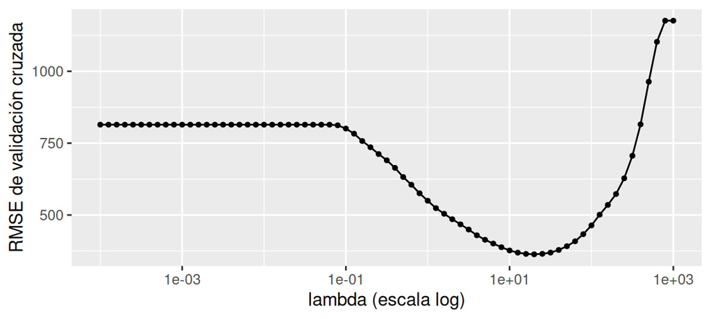

- `autoplot()` dibuja la media de cada $\lambda$ (en escala logarítmica); se prueba el rango hasta encontrar la U
  - ojo: es solución «interior»; a veces, *zoom*

```r
show_best(ajuste, metric = "rmse", n = 3)
```

```
# A tibble: 3 × 7
  penalty .metric .estimator  mean     n std_err
    <dbl> <chr>   <chr>      <dbl> <int>   <dbl>
1   19.95 rmse    standard   363.3    10   13.26
2   15.85 rmse    standard   364.7    10   13.84
3   25.12 rmse    standard   365.0    10   12.93
# ℹ 1 more variable: .config <chr>
```

- `show_best()` ordena de mejor a peor la media de una métrica (p. ej., RMSE)
  - notad: diferencias en la métrica menores que un error estándar

```r
mejor  <- select_best(ajuste, metric = "rmse")   # lambda = 20,0 (RMSE 363,3: menor error medio)
simple <- select_by_one_std_err(ajuste, desc(penalty), metric = "rmse")   # lambda = 31,6 (RMSE 369,2)
```

- `select_by_one_std_err()` aplica la **regla de un error estándar**: el mayor $\lambda$ (`desc()`), es decir, el modelo más simple, cuyo error está a menos de un error estándar del mínimo

## PRÁCTICA en clase (1): la receta del modelo flexible

La tienda quiere predecir el gasto de los clientes nuevos con el modelo flexible del Tema 06, pero escrito como receta, para poder añadirle después pasos que la fórmula no permite (estandarizar, imputar). Con vuestro DNI como semilla y la partición de la transparencia «Partición inicial»:

1. Escribid el modelo flexible como receta: logaritmo de la renta, polinomios de grado 4 en edad y renta, dummies de estudios y zona, y todas las interacciones de dos en dos, y estandarizad las columnas. Afinad $\lambda$ con `workflow(receta, lasso)`, los mismos bloques y la misma rejilla, y comparad $\lambda$ y el RMSE de validación cruzada con los de la fórmula.
2. En tres frases: qué aprende `prep()` en esta receta, qué hace `bake()` con la muestra de prueba, y por qué dentro de `tune_grid()` la receta se prepara en cada bloque y no una vez con todo el entrenamiento

**Nota**

**Ahora el ejercicio: entrega 1, apartados a) y b).**

# Paso 5: finalizar y evaluar

## Finalizar y evaluar

```r
final <- finalize_workflow(flujo, mejor) |>   # a mano: tibble(penalty = 8.5)
  last_fit(part, metrics = metric_set(rmse, mae))
```

- `finalize_workflow()` cambia `tune()` por el valor elegido ($\lambda = 20$): sale un flujo completo
- `last_fit()` recibe ese flujo y `part`, y hace los dos últimos pasos del proceso, en este orden:
  1. estima el flujo en **todo** el entrenamiento (los 323 clientes, sin bloques)
  2. predice los 81 clientes de prueba y calcula las métricas, una sola vez
- En `final` queda guardado todo, y se puede extraer con funciones:
  - `extract_workflow()` saca el flujo estimado, que se usa con las mismas funciones que ya vimos para la estimación sin hiperparámetros de `mco` (`tidy()`, `predict()`, `augment()`)

```r
collect_metrics(final)              # el error de prueba: RMSE 339,6 y MAE 278,5
collect_predictions(final)          # ventas y .pred de los 81 clientes de prueba
extract_workflow(final) |> tidy()   # coeficientes: 39 de 143 no son cero
```

- Se informa del error de **prueba**: los de entrenamiento y validación cruzada también se han calculado, pero no sirven para eso
  - con el entrenamiento se estimó el modelo y se eligió $\lambda$, y su error sale optimista (anexo)

# Niveles o logaritmos

## El gasto en logaritmos y el error en euros

```r
tienda_l <- tienda |> mutate(lventas = log(ventas))
set.seed(12345678)
part_l    <- initial_split(tienda_l, prop = 0.8)       # paso 1: la misma partición
formula_l <- lventas ~ (poly(edad, 4) + poly(log(renta), 4) +    # paso 2
                          educ + mujer + descuento + zona)^2
flujo_l   <- workflow(formula_l, lasso)
bloques_l <- vfold_cv(training(part_l), v = 10)        # paso 3: los mismos bloques
ajuste_l  <- tune_grid(flujo_l, resamples = bloques_l, grid = rejilla,    # paso 4
                       metrics = metric_set(rmse, mae),
                       control = control_grid(save_pred = TRUE))
mejor_l   <- select_best(ajuste_l, metric = "rmse")
final_l   <- finalize_workflow(flujo_l, mejor_l) |> last_fit(part_l)     # paso 5
```

- Los mismos cinco pasos con otra respuesta, que cambia solo en la fórmula
  - cualquier transformación de la respuesta se hace **antes** de partir, con `mutate()` (errores frecuentes)
- El RMSE de validación cruzada sale **en logaritmos**: 0,113 ($e^{0{,}113} = 1{,}12$, un error típico del 12 % del gasto)
  - para elegir entre el modelo en niveles y el de logaritmos, los errores tienen que estar **en las mismas unidades**
  - si uno de los modelos va en logaritmos y los datos son muy dispersos, mejor comparar por MAE
  - se deshace el logaritmo en las predicciones de evaluación, guardadas con `save_pred = TRUE`:

```r
collect_predictions(ajuste_l, parameters = mejor_l) |>
  mutate(ventas = exp(lventas), pred = exp(.pred)) |> rmse(ventas, pred)   # 400 euros
```

- En euros, el modelo en logaritmos se equivoca más (400) que el de niveles (363): se predice en niveles

## Predecir un cliente nuevo: niveles y logaritmos

```r
nuevo <- tibble(renta = 2000, edad = 40, mujer = 1, descuento = 0,
                educ = factor(12, levels = levels(tienda$educ)),
                zona = factor("ciudad", levels = levels(tienda$zona)))
predict(extract_workflow(final), new_data = nuevo)       # en niveles: 5.028 €
```

```
# A tibble: 1 × 1
  .pred
  <dbl>
1 5028.
```

```r
predict(extract_workflow(final_l), new_data = nuevo) |>
  mutate(euros = exp(.pred))                            # en logaritmos: 5.088 €
```

```
# A tibble: 1 × 2
  .pred euros
  <dbl> <dbl>
1 8.535 5088.
```

- Las variables cualitativas del cliente nuevo llevan las mismas categorías que en los datos

## PRÁCTICA en clase (2): ¿niveles o logaritmos?

La tienda tiene que elegir un modelo para predecir el gasto de los clientes nuevos y quiere el error en euros, porque es lo que entiende quien decide. Con vuestro DNI como semilla:

1. Afinad el LASSO con el gasto en logaritmos: la misma fórmula con `lventas`, la misma rejilla y los mismos bloques. ¿Qué $\lambda$ sale? ¿Qué significa el RMSE de validación cruzada que da `show_best()`, y qué es `exp()` de ese número?
2. Calculad el error en euros del modelo en logaritmos, en validación cruzada y en prueba, y ponedlo al lado del modelo en niveles (RMSE y MAE). ¿Con cuál predecís?
3. Un cliente nuevo tiene 55 años, 3.000 € de renta, 16 años de estudios, vive en la capital, es hombre y tiene descuento. ¿Cuánto gastará según cada modelo? ¿Qué predicción le daríais a la tienda, y por qué?

**Nota**

**Ahora el ejercicio: entrega 2, apartados a) a c).**

# Clasificación: a quién vigilar

## El abandono con `logistic_reg()`

```r
churn <- read_csv("data/churn_clientes.csv") |>
  select(-id_cliente, -plan_tipo) |>
  mutate(across(where(is.character), factor),
         churn = factor(churn, levels = c("Sí", "No")))
set.seed(12345678)
part_c    <- initial_split(churn, prop = 0.8, strata = churn)       # 1. partir
logit     <- logistic_reg(penalty = tune(), mixture = 1) |>         # 2. modelo
  set_engine("glmnet")
flujo_c   <- workflow(churn ~ ., logit)                             #    y flujo
bloques_c <- vfold_cv(training(part_c), v = 10, strata = churn)     # 3. bloques
ajuste_c  <- tune_grid(flujo_c, resamples = bloques_c,              # 4. afinar
                       grid = rejilla, metrics = metric_set(roc_auc))
```

- Los mismos cinco pasos con los 600 clientes del Tema 06 (60 % de abandono)
- Respecto a la regresión cambian tres cosas:
  - el tipo de modelo, `logistic_reg()`, que se estima por verosimilitud más la penalización (Tema 06), y la métrica con la que solo se elige $\lambda$, `roc_auc`
  - `strata = churn` mantiene el 60 % de abandono en entrenamiento (479 clientes), prueba (121) y bloques
  - `churn` lleva «Sí» como **primer nivel**, porque las métricas toman el primer nivel como el suceso: así `roc_auc()` y `sens()` miran el abandono (errores frecuentes)
- Todas las cualitativas pasan a factor antes de partir, igual que `educ` en la tienda (errores frecuentes)
  - no toda columna de texto es cualitativa (un identificador), ni toda cualitativa es texto (`educ`)

## Evaluar en prueba y elegir el umbral a mano

```r
mejor_c <- select_best(ajuste_c, metric = "roc_auc")
final_c <- finalize_workflow(flujo_c, mejor_c) |>                    # 5. finalizar y evaluar
  last_fit(part_c, metrics = metric_set(roc_auc, accuracy))
collect_metrics(final_c) |> select(.metric, .estimate)
```

```
# A tibble: 2 × 2
  .metric  .estimate
  <chr>        <dbl>
1 accuracy    0.6860
2 roc_auc     0.7489
```

- `augment(final_c)` devuelve los 121 clientes de prueba con tres columnas nuevas: las probabilidades `.pred_Sí` y `.pred_No`, y la clase predicha `.pred_class`, que usa el umbral 0,5
- El umbral puede ser una decisión de la empresa (para hacer distintas promociones): se elige a mano y se calculan las métricas habituales:

```r
augment(final_c) |>
  mutate(oferta = .pred_Sí > 0.5,   # 6 meses gratis: umbral 6/12 (Tema 06)
         pred = factor(if_else(oferta, "Sí", "No"), levels = c("Sí", "No"))) |>
  sens(churn, pred)      # 0,81; también spec(), precision(), accuracy(), conf_mat()
```

## PRÁCTICA en clase (3): a quién vigilar, evaluado de verdad

La empresa del Tema 06 quiere un modelo de abandono evaluado con clientes que el modelo no haya visto, y decidir con él cuántos meses gratis ofrecer. Con vuestro DNI como semilla y los objetos de la transparencia «El abandono con `logistic_reg()`»:

1. Afinad $\lambda$ por AUC con `tune_grid()`. ¿Qué $\lambda$ elige `select_best()` y qué AUC de validación cruzada tiene? Con la regla de un error estándar, ¿cuántos coeficientes quedan distintos de cero y cuánto AUC se pierde?
2. Finalizad el flujo con el mejor $\lambda$ y evaluadlo con `last_fit()`. Comparad el AUC de prueba con el de validación cruzada. Explicad qué ha hecho `last_fit()` por dentro, en qué orden, y por qué los dos números pueden diferir
3. Con los clientes de prueba, calculad para $k$ = 3, 6 y 9 meses cuántos recibirían la oferta y el ahorro neto de cada $k$: un año de cuota (12 × `precio_mensual`) por cada cliente con oferta que de verdad se iba, menos $k$ meses de cuota por cada oferta. ¿Qué $k$ elegís, y qué supuesto hace falta para que esa cuenta valga?

**Nota**

**Ahora el ejercicio: entrega 3, apartados a) a c).**